# EDA Final Report

Lucy Lu (xl2602), Hanlin Wu (hw2576)

## Introduction

> In this section, explain why you chose this topic, and the questions you are interested in studying. Include a brief description of how you found the data, and clear instructions on where the reader can find the data.

International travel has become so easy that anyone can just grab his/her bags and documents and starts a new journey. As one of the most tourists importing and exporting countries, the USA has always played a significant role in world’s tourism industry. Therefore, we want to study people who traveled to and from the USA by investigating the Travel and Tourism Statistical data provided by The National Travel & Tourism Office (NTTO). To be more precise, we want to answer following questions:

- What are the most popular international travel destinations for Americans?
- What are the main regions of people who travel to the USA?
- What are the purposes and spending of travels to and from the USA?
- Does the economy matter for the answers to above questions?

Data is collected from two resources,

- `National Travel & Tourism Office (NTTO)`:
  - [`Inbound Information`](http://travel.trade.gov/outreachpages/inbound.general_information.inbound_overview.html)
  - [`Outbound Information`](http://travel.trade.gov/outreachpages/outbound.general_information.outbound_overview.html)
- [`World Bank`](http://data.worldbank.org/indicator/NY.GDP.MKTP.CD):

Although NTTO provides plenty of information we need, it is not easy to collect and combine them together. There is much unavoidable manual work to do in the collecting process because of the inconsistent formatting (data formats may vary from year to year), file types (some are pdfs) and location of these files. For example, in order to get monthly arrival information per region, we have to download each year’s excel files, and then clean, select and combine them into a final master table that is easier to manipulate with in R.

In the end, we collect several master tables from NTTO: yearly spending per region with three categories, total monthly spending with three categories, monthly inbound visitation per country and monthly outbound visitation per country. We may use other tables as complementary tables.

GDP data from World Bank is easier to clean. Further, we will load these tables to R and use dplyr and tidyr to fit the data for our analysis.

## Team

> List team members and a description of how each contributed to the project. (If you’re working alone, briefly describe the stages of the project.)
- Lucy Lu: finding and organizing the data, compiling visualization and stories, creating the interactive app, focusing on the import part.
- Hanlin Wu: cleaning the data, testing various visualizations, creating the interactive app, focusing on the export part.

## Analysis of Data Quality

> Provide a detailed, well-organized description of data quality, including textual description, graphs, and code.

```r
library(tidyverse)
library(viridis)
library(ggvis)
library(extracat)
```

```r
raw_ntto_spend_y <- tbl_df(read.csv("clean_data/clean_yearly_spending_region.csv", header = TRUE))
raw_ntto_spend_m <- tbl_df(read.csv("clean_data/Monthly_Exports_Imports_Balance.csv", header = TRUE))
raw_ntto_inbound_m <- tbl_df(read.csv("clean_data/clean_monthly_visitation_inbound_country.csv", header = TRUE))
raw_ntto_outbound_m <- tbl_df(read.csv("clean_data/clean_monthly_us_to_international.csv", header = TRUE))
raw_wb_gdp <- tbl_df(read.csv("clean_data/API_NY.GDP.MKTP.CD_DS2_en_csv_v2.csv", header = TRUE, skip=4))
```

Data we have are: monthly spending from NTTO, yearly spending from NTTO, monthly inbound from NTTO, monthly outbound from NTTO and GDP from Word Bank. In order to analyze data quality of our data, we need first to take a look at them.

*Output of `str` has been truncated to get a more compact look in report*

- Yearly Spending from NTTO

```r
str(raw_ntto_spend_y, list.len=5)
```

```
Classes 憈bl_df? 憈bl? and 'data.frame':  48 obs. of  13 variables:
 $ region  : Factor w/ 8 levels "Africa","Asia-Pacific",..: 1 1 1 1 1 1 2 2 2 2 ...
 $ type    : Factor w/ 2 levels "Payments (imports)",..: 2 2 2 1 1 1 2 2 2 1 ...
 $ category: Factor w/ 3 levels "Education related",..: 1 2 3 1 2 3 1 2 3 1 ...
 $ X2006   : int  930 208 1390 137 29 1740 8566 836 23160 626 ...
 $ X2007   : int  961 183 1594 161 30 2435 9455 810 24756 667 ...
  [list output truncated]
```

- Monthly Spending from NTTO

```r
str(raw_ntto_spend_m, list.len=4)
```

```
Classes 憈bl_df? 憈bl? and 'data.frame':  10 obs. of  219 variables:
 $ X      : Factor w/ 2 levels "Exports (Receipts)",..: 1 1 1 1 1 2 2 2 2 2
 $ X.1    : Factor w/ 8 levels "Medical/Education/Workers Spending",..: 4 7 8 1 3 5 6 8 1 2
 $ Jan.99 : Factor w/ 10 levels "$1,372 ","$1,467 ",..: 10 9 7 1 3 8 6 5 4 2
 $ Feb.99 : Factor w/ 10 levels "$1,377 ","$1,496 ",..: 10 9 7 1 3 8 6 5 4 2
  [list output truncated]
```

- Monthly Inbound from NTTO

```r
str(raw_ntto_inbound_m, list.len=5)
```

```
Classes 憈bl_df? 憈bl? and 'data.frame':  132 obs. of  32 variables:
 $ year                       : int  2015 2015 2015 2015 2015 2015 2015 2015 2015 2015 ...
 $ MONTH                      : Factor w/ 12 levels "APRIL","AUGUST",..: 5 4 8 1 9 7 6 2 12 11 ...
 $ TOTAL.ARRIVALS             : Factor w/ 132 levels "2,592,882","2,624,018",..: 91 70 109 119 124 110 130 131 120 121 ...
 $ CANADA                     : Factor w/ 132 levels "1,007,315","1,029,277",..: 63 39 109 96 89 50 112 120 71 44 ...
 $ MEXICO                     : Factor w/ 132 levels "1,004,126","1,007,303",..: 44 18 27 50 52 38 53 57 35 55 ...
  [list output truncated]
```

- Monthly Outbound from NTTO

```r
str(raw_ntto_outbound_m, list.len=4)
```

```
Classes 憈bl_df? 憈bl? and 'data.frame':  102 obs. of  14 variables:
 $ Year   : int  2015 2015 2015 2015 2015 2015 2015 2015 2015 2015 ...
 $ Regions: Factor w/ 24 levels "Africa","Asia",..: 10 8 2 20 9 19 17 1 22 16 ...
 $ Jan    : Factor w/ 102 levels "1,707,635","1,716,026",..: 96 91 59 16 47 89 20 49 31 37 ...
 $ Feb    : Factor w/ 102 levels "1,514,915","1,580,058",..: 79 94 59 16 50 98 17 39 30 35 ...
  [list output truncated]
```

- GDP from Word Bank

```r
str(raw_wb_gdp, list.len=6)
```

```
Classes 憈bl_df? 憈bl? and 'data.frame':  264 obs. of  62 variables:
 $ Country.Name  : Factor w/ 264 levels "Afghanistan",..: 11 1 6 2 5 8 250 9 10 4 ...
 $ Country.Code  : Factor w/ 264 levels "ABW","AFG","AGO",..: 1 2 3 4 5 6 7 8 9 10 ...
 $ Indicator.Name: Factor w/ 1 level "GDP (current US$)": 1 1 1 1 1 1 1 1 1 1 ...
 $ Indicator.Code: Factor w/ 1 level "NY.GDP.MKTP.CD": 1 1 1 1 1 1 1 1 1 1 ...
 $ X1960         : num  NA 5.38e+08 NA NA NA ...
 $ X1961         : num  NA 5.49e+08 NA NA NA ...
  [list output truncated]
```

```r
raw_ntto_spend_m %>%
   gather(mon.year, spend, -X, -X.1)
```

```
attributes are not identical across measure variables; they will be dropped
```

| X | X.1 | mon.year | spend |
| --- | --- | --- | --- |
| Exports (Receipts) | Total Travel and Tourism-Related Exports | Jan.99 | $8,937 |
| Exports (Receipts) | Travel Receipts (for all purposes including education) | Jan.99 | $7,386 |
| Exports (Receipts) | Travel Spending | Jan.99 | $6,014 |
| Exports (Receipts) | Medical/Education/Workers Spending | Jan.99 | $1,372 |
| Exports (Receipts) | Passenger Fare Receipts | Jan.99 | $1,551 |
| Imports (Payments) | Total Travel and Tourism-Related Imports | Jan.99 | $6,348 |
| Imports (Payments) | Travel Payments (for all purposes including education) | Jan.99 | $4,881 |
| Imports (Payments) | Travel Spending | Jan.99 | $4,700 |
| Imports (Payments) | Medical/Education/Workers Spending | Jan.99 | $181 |
| Imports (Payments) | Passenger Fare Payments | Jan.99 | $1,467 |

[output cut: 990 more lines]

```r
country_str <- 'Argentina|Australia|Brazil|Canada|Chile|China|Colombia|France|Germany|India|Italy|Japan|Mexico|Netherlands|Russia|Saudi Arabia|South Korea|Singapore|Spain|Sweden|Switzerland|Taiwan|United Kingdom|United States'
tidy_ntto_spend_y <- raw_ntto_spend_y %>%
   gather(x_year, spend, -region, -type, -category) %>%
   separate(x_year, c("X", "Year"), sep="X") %>%
   select(-X) %>%
   select(Region=region, Type=type, Category=category, Year=Year,Spend=spend) %>%
   mutate(Missing = ifelse(is.na(Spend), "yes", "no"))
tidy_wb_gdp <- raw_wb_gdp %>%
   select(-Indicator.Name, -Indicator.Code, -X) %>%
   gather(x_year, GDP, -Country.Name, -Country.Code) %>%
   filter(grepl(country_str, Country.Name)) %>%
   separate(x_year, c("X", "Year"), sep="X") %>%
   select(-X) %>%
   select(CountryName=Country.Name, CountryCode=Country.Code, Year=Year, GDP=GDP) %>%
   # filter(year>1999) %>%
   mutate(missing = ifelse(is.na(GDP), "yes", "no"))
```

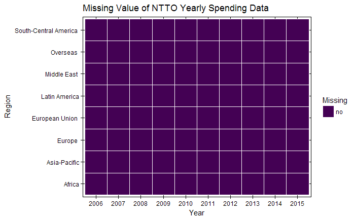

```r
ggplot(tidy_ntto_spend_y, aes(x=Year, y=Region, fill = Missing)) +
   geom_tile(color = "white") +
   scale_fill_viridis(discrete = TRUE) +
   ggtitle("Missing Value of NTTO Yearly Spending Data") +
   theme_linedraw()
```

```r
   # theme(axis.text.x=element_text(angle=90))
```

```r
ggplot(tidy_wb_gdp, aes(x=Year, y=Country.Name,  fill = Missing)) +
   geom_tile(color = "white") +
   scale_fill_viridis(discrete = TRUE) +
   ggtitle("Missing Value of All Interested Countries (1960-2016)") +
   theme_linedraw() +
   theme(axis.text.x=element_text(angle=90))
```

[output not shown]

[output not shown]

## Executive Summary

• Title, axis labels, tick mark labels, and legends should be comprehensible (easy to understand) and legible (easy to read / decipher).

• Tick marks should not be labeled in scientific notation or with long strings of zeros, such as 3000000000. Instead, convert to smaller numbers and change the units: 3000000000 becomes “3” and the axis label “billions of views”.

• Units should be intuitive (Extreme example: an axis labeled in month/day/year format is intuitive, one labeled in seconds since January 1, 1970 is not.)

• The font size should be large enough to read clearly. The default in ggplot2 is generally too small. You can easily change it by passing the base font size to the theme, such as + theme_grey(16). (The default base font size is 11.)

• The order of items on the axes and legends is logical. (Alphabetical is often not logical.)

• Colors should be color vision deficiency friendly.

• If a legend is taking up too much space on the right, move it to the bottom.

• If categorical variable levels are long, set up the graph so the categorical variable is on the y-axis and the names are horizontal. A better option, if possible, is to shorten the names of the levels.

• Not all EDA graphs lend themselves to presentation, either because the graph form is hard to understand without practice or it’s not well labeled. The labeling problem can be solved by adding text in an image editor. The downside is that it is not reproducible. If you want to go this route, Paintbrush is a free and simple bitmap image editor for the Mac: https://paintbrush.sourceforge.io/ There are many other options.

• Err on the side of simplicity. Don’t, for example, overuse color when it’s not necessary. Ask yourself: does color make this graph any clearer? If it doesn’t, leave it out.

• Test your graphs on nontechnical friends and family and ask for feedback.

## Main Analysis

• The guidelines for the Executive Summary above do NOT apply to exploratory data analysis. Your main concern is designing graphs that reveal patterns and trends.

• As noted in Hmk #4, do not use circles, that is: bubbles, pie charts, or polar coordinates.

• Use stacked bar charts sparingly. Try grouped bar charts and faceting as alternatives, and only choose stacked bar charts if they truly do a better job than the alternatives for observing patterns.

#### Challenges

There are some challenges in our project: